# Motor Development Survey Analysis

Shari Liu

11/11/2018

# Working with empirical dataset

Across two experiments, we found that by 13 months of age, infants are sensitive to the perils of other people’s actions. We tested this in the context of cliffs of varying depth – the deeper the cliff, the more dangerous the action. We tested both 10 and 13mo infants in these experiments, and found robust evidence for sensitivity to danger in 13mo, and more mixed evidence at 10mo. One key question is why: Why do 13mo succeed more robustly than 10mo? This report explores one potential cause of this finding, which is that 13mo have more experience navigating through the world themselves, and thus have more first-person experience with potentially dangerous situations (e.g. cruising along walls, pulling themselves up to stand, etc).

This report asks 2 questions:

1. Are there differences in the motor competencies of 10 and 13mo in these experiments?
2. If yes, do these differences predict differences in performance on their analysis of other agents’ perils?

## Descriptives

```r
setwd("~/Documents/HarvardLDS/Studies/RISK/github/analyses")

original <- read.csv("motordata_combined.csv")

str(original)
```

```
## 'data.frame':    130 obs. of  76 variables:
##  $ X                 : int  1 2 3 4 5 6 7 8 9 10 ...
##  $ reliability       : int  1 1 0 0 1 0 1 0 1 1 ...
##  $ rn                : int  425937 201516 524991 201729 201375 185848 201770 201644 525925 201629 ...
##  $ subj_orig.x       : logi  NA NA NA NA NA NA ...
##  $ sex               : Factor w/ 2 levels "f","m": 1 1 2 1 2 2 2 1 2 2 ...
##  $ subj              : Factor w/ 124 levels "01-MR","02-MR",..: 1 2 3 4 5 6 7 8 9 10 ...
##  $ agem              : num  10.1 12.9 10.1 12.7 13.5 ...
##  $ experiment.x      : Factor w/ 4 levels "MR10","MR13",..: 1 2 1 2 2 2 2 2 2 2 ...
##  $ cost              : Factor w/ 1 level "Risk": 1 1 1 1 1 1 1 1 1 1 ...
##  $ HV_side           : Factor w/ 3 levels "","left","right": 1 1 1 1 1 1 1 1 1 1 ...
##  $ first_test        : Factor w/ 4 levels "high","HV","low",..: 3 3 3 1 1 1 1 3 3 1 ...
##  $ first_fam         : Factor w/ 4 levels "fam1","fam2",..: 1 1 2 2 2 2 2 1 2 1 ...
##  $ first_test_scene  : Factor w/ 3 levels "","HL","LH": 3 3 2 3 3 3 3 3 2 2 ...
##  $ prefam_config     : Factor w/ 3 levels "","HL","LH": 2 2 2 3 3 3 3 2 2 3 ...
```

[output cut: 62 more lines]

```r
action_ages_full <- original %>%
  select(-ends_with("y.n")) %>%
  gather(action,age, reaches:walks) %>%
  mutate(age = as.numeric(as.character(age))) %>%
  spread(action,age) %>%
  select(X, crawls:waves)
action_ages <- as.data.frame(action_ages_full) %>%
  rename(subj = X) %>%
  as.data.frame()

# categories of behaviors
objectdirected <- c("reaches", "handtohand", "pincer", "hiddensearch")
selflocomotion <- c("rolls", "sits", "crawls", "pullstand", "stands", "cruises",  "walks")
anxiety <- c("strangerdanger", "fearheights")
social <- c("waves", "points")


data <- original %>% select(-ends_with("y.n")) %>%
  # mutate(diff = avg.higher - avg.lower) %>%
  gather(action,age, reaches:walks) %>%
  mutate(age = as.numeric(as.character(age))) %>%
  spread(action,age) %>%
  select(X, experiment.x, agem, age.at.survey, prop.lower, prop.higher, avg.lower, avg.higher, crawls:waves) %>%
  mutate(X = as.factor(X)) %>%
  rename(subj=X, age.at.study=agem) %>%
  mutate(exp = as.factor(case_when(experiment.x == "MR13" | experiment.x=="MR10" ~ "MR",
                         experiment.x == "RISK10" | experiment.x=="RISK13" ~ "RISK"))) %>%
  mutate(agegroup = as.factor(case_when(age.at.study<12 ~ "10", age.at.study>12 ~ "13")))%>%
  mutate(looking.to.unexp = case_when (exp == "MR" ~ prop.higher,
                                       exp == "RISK" ~ prop.lower)) %>%
  mutate(LTdiff = case_when(exp == "MR" ~ avg.higher-avg.lower,
                            exp == "RISK" ~ avg.lower-avg.higher)) %>%
  gather(action,age,crawls:waves) %>%
  mutate(category = as.factor(case_when(action %in% objectdirected ~ "objectdirected",
                              action %in% selflocomotion ~ "selflocomotion",
                              action %in% anxiety ~ "anxiety",
                              action %in% social ~ "social"))) %>%
  mutate(monthsPerformed = age.at.study-age)
data.yn <- original %>% select(X, experiment.x, ends_with("y.n")) %>%
  gather(action, yesno, reaches_y.n:walks_y.n) %>%
  mutate(yesno = tolower(yesno)) %>%
  mutate(action = str_remove(action, "_y.n")) %>%
  mutate(X = as.factor(X)) %>%
  rename(subj=X)
full_data <- full_join(data.yn, data) %>%
    mutate(yesnoAtStudy = case_when(age.at.survey-age.at.study<.25 & yesno=="yes" ~ 1,
                                    age.at.survey-age.at.study<.25 & yesno=="no" ~ 0,
                                    age > age.at.study ~ 0,
                                    age <= age.at.study ~ 1))
full_data %>% filter(is.na(yesnoAtStudy) & is.na(age)) %>%
  group_by(subj) %>% summarize(n=n()) %>%
  filter(n==15)
```

```
## # A tibble: 36 x 2
##    subj      n
##    <fct> <int>
##  1 9        15
##  2 11       15
##  3 12       15
##  4 16       15
##  5 17       15
##  6 20       15
##  7 24       15
##  8 67       15
##  9 68       15
## 10 71       15
## # … with 26 more rows
```

## Question 1: Are there differences in motor competence at 10 and 13mo?

First, let’s just see when infants begin reliably doing things.

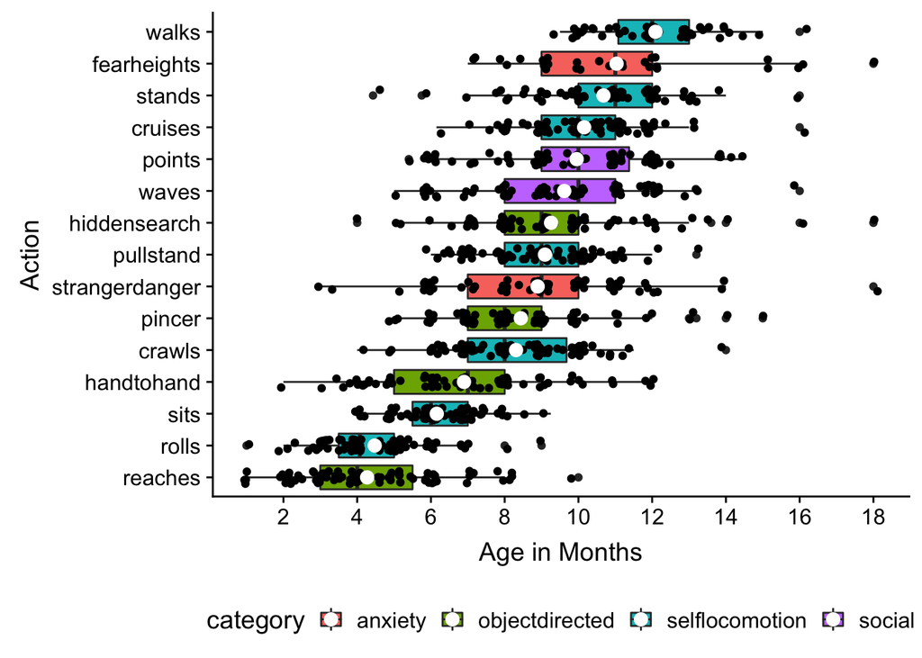

```r
# age in months of all actions, grouped by category
full_data$action <- as.factor(full_data$action)
ggplot(data = full_data %>% na.omit(), aes(x=reorder(action,age), y=age, fill=category)) +
  geom_boxplot()+
  geom_jitter(width=.2, height=0.2)+
  stat_summary(fun.y=mean, geom="point", colour="white", size=3)+
  scale_y_continuous(breaks=seq(0,20,2))+
  coord_flip() +
  # theme_bw(20) +
  xlab("Action")+
  ylab("Age in Months")+
  theme(legend.position="bottom")
```

Here’s a plot of how many months of experience kids have with each action, relative to the day they participated in the study. Unsurprisingly, 13mo have a lot more experience with all actions.

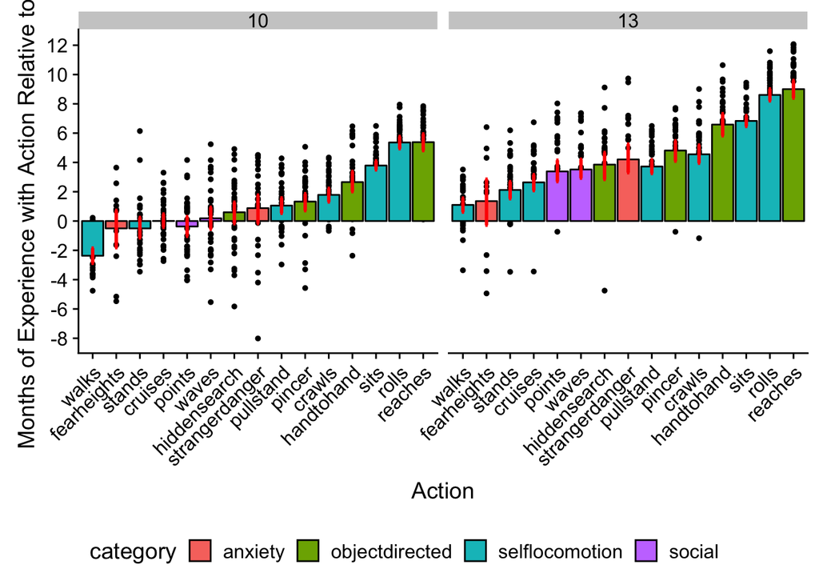

```r
data %>%
  na.omit() %>%
  ggplot(aes(reorder(action,monthsPerformed),monthsPerformed, fill=category)) +
  # ggplot(aes(agegroup,monthsPerformed, fill=category)) +
  geom_jitter(width=0, height=0.1, size=1)+
  stat_summary(fun.y="mean", geom="bar", colour="black")+
  stat_summary(fun.data=mean_cl_boot, geom="errorbar", colour="red", width=0.1, size=1)+
  # coord_flip()+
  scale_y_continuous(breaks=seq(-12,12,2))+
  xlab("Action")+
  ylab("Months of Experience with Action Relative to Study")+
  facet_wrap(~agegroup)+
  # facet_wrap(~action)+
  theme(legend.position="bottom", axis.text.x = element_text(angle = 45, hjust = 1))
```

Next, we can look at differences in the proportion of 13mo and 10mo participants across all our actions. If the 95% CIs do not overlap (e.g. for 10mo an estimate is .3-.5 and for 13mo .55-.8), then we can say that there are reliable differences across these two groups on that action.

```r
prop_data <- full_data %>%
  na.omit() %>%
  group_by(category,action, agegroup,yesnoAtStudy) %>%
  summarise(n = n()) %>%
  mutate(freq = n / sum(n)) %>%
  mutate(total = sum(n)) %>%
  as.data.frame()

for (i in 1:nrow(prop_data)){
  prop_data$lower[i] <- exactci(prop_data$n[i], prop_data$total[i], conf.level=0.95)$conf.int[1]
  prop_data$upper[i] <- exactci(prop_data$n[i], prop_data$total[i], conf.level=0.95)$conf.int[2]
}

prop_data %>%
  filter(yesnoAtStudy==1)
```

```
##          category         action agegroup yesnoAtStudy  n   freq total
## 1         anxiety    fearheights       10            1  8 0.5333    15
## 2         anxiety    fearheights       13            1 11 0.7857    14
## 3         anxiety strangerdanger       10            1 24 0.7742    31
## 4         anxiety strangerdanger       13            1 26 1.0000    26
## 5  objectdirected     handtohand       10            1 33 0.9167    36
## 6  objectdirected     handtohand       13            1 31 0.9688    32
## 7  objectdirected   hiddensearch       10            1 28 0.7000    40
## 8  objectdirected   hiddensearch       13            1 29 0.9667    30
## 9  objectdirected         pincer       10            1 35 0.8750    40
## 10 objectdirected         pincer       13            1 32 0.9697    33
## 11 objectdirected        reaches       10            1 40 1.0000    40
## 12 objectdirected        reaches       13            1 38 1.0000    38
## 13 selflocomotion         crawls       10            1 35 0.9211    38
## 14 selflocomotion         crawls       13            1 41 0.9762    42
```

[output cut: 47 more lines]

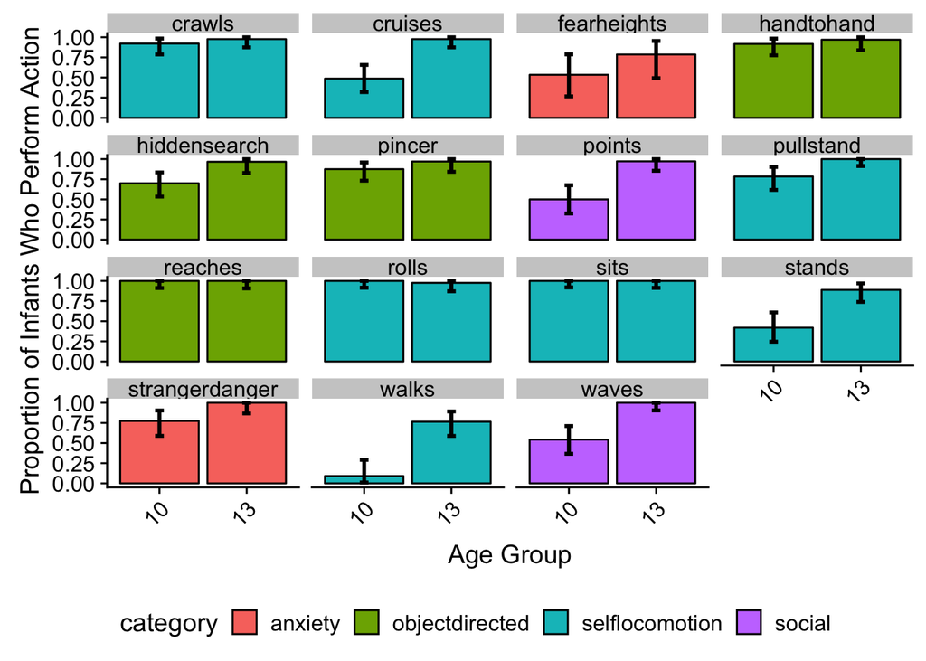

```r
prop_data %>%
  filter(yesnoAtStudy==1) %>%
  # ggplot(aes(reorder(action,freq),freq, fill=category)) +
  ggplot(aes(agegroup,freq, fill=category)) +
  geom_bar(stat="identity", colour="black")+
  geom_errorbar(aes(ymin=lower, ymax=upper), width=0.1, size=1)+
  xlab("Age Group")+
  ylab("Proportion of Infants Who Perform Action")+
  # facet_wrap(~agegroup)+
  facet_wrap(~action)+
  theme(legend.position="bottom", axis.text.x=element_text(angle=45,hjust=1))
```

Here’s the same plot organized by age group, instead of action.

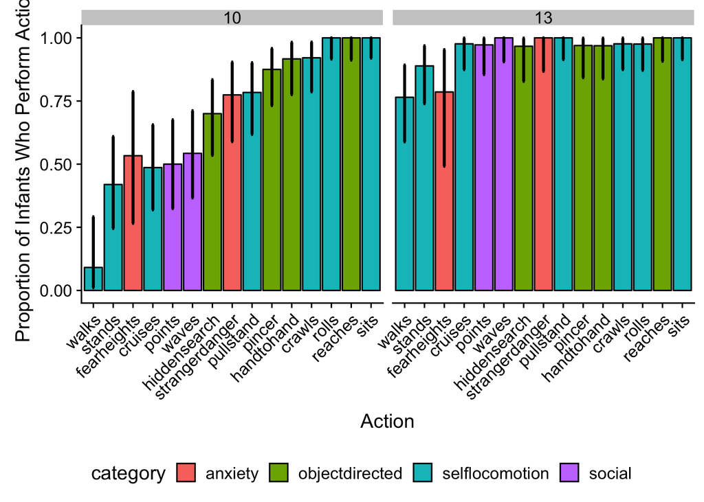

```r
prop_data %>%
  filter(yesnoAtStudy==1) %>%
  ggplot(aes(reorder(action,freq),freq, fill=category)) +
  # ggplot(aes(agegroup,freq, fill=category)) +
  geom_bar(stat="identity", colour="black")+
  geom_errorbar(aes(ymin=lower, ymax=upper), width=0.1, size=1)+
  xlab("Action")+
  ylab("Proportion of Infants Who Perform Action")+
  facet_wrap(~agegroup)+
  # facet_wrap(~action)+
  theme(legend.position="bottom", axis.text.x=element_text(angle=45,hjust=1))
```

## Question 2: Do differences in motor competence predict infants’ performance?

Ok, so there definitely are differences in the motor competencies across the two age groups in our study. The next question is whether these differences actually predict infants’ looking times.

Here’s a plot looking at infants’ looking times, organized by whether they do or don’t reliably perform a given action at the time of their participation in the looking time study.

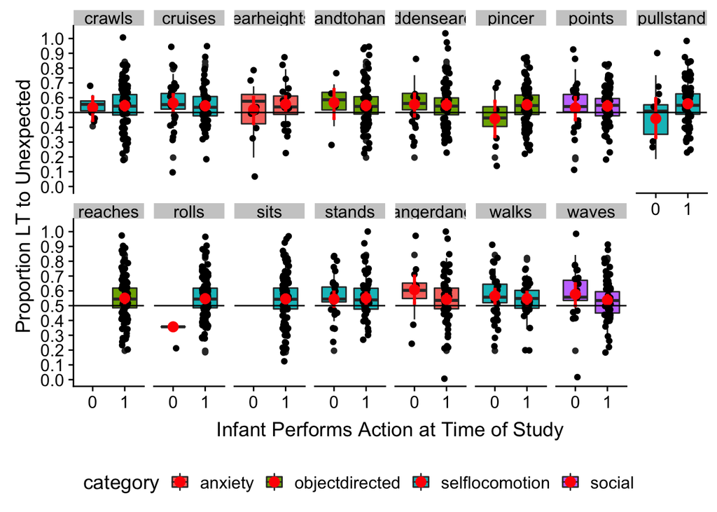

```r
full_data %>%
  na.omit() %>%
ggplot(aes(reorder(as.factor(yesnoAtStudy),looking.to.unexp),looking.to.unexp, fill=category))+
  geom_boxplot()+
  geom_jitter(width=.1, height=0.2)+
  stat_summary(fun.y=mean, geom="point", colour="red", size=3)+
  stat_summary(fun.data="mean_cl_boot", geom="errorbar", colour="red", width=0.1, size=1)+
  facet_wrap(~action,nrow=2)+
  geom_hline(yintercept = .50) +
  scale_y_continuous(breaks=seq(0,1,.1))+
  xlab("Infant Performs Action at Time of Study")+
  ylab("Proportion LT to Unexpected")+
  theme(legend.position="bottom")
```

Here’s a plot relating how many months of experience kids have with a given action and their looking times.

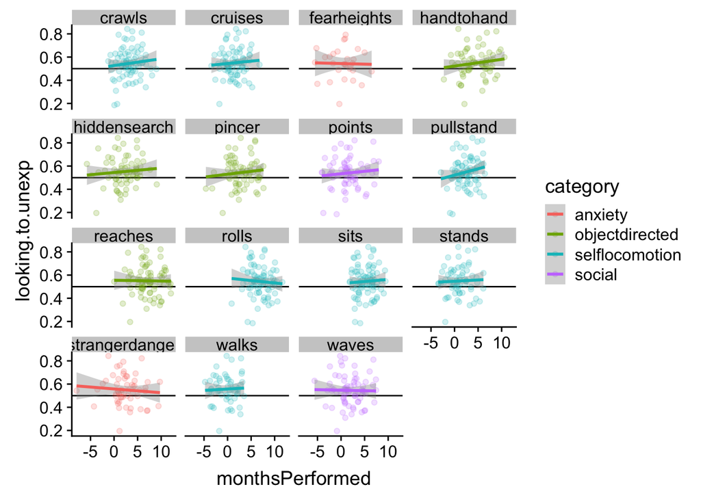

```r
full_data %>%
  na.omit() %>%
  ggplot(aes(monthsPerformed, looking.to.unexp, colour=category))+
  geom_hline(yintercept = .50) +
  geom_point(alpha=0.2)+
  geom_smooth(method="lm")+
  facet_wrap(~action)
```

Ok, so far, we don’t see much signal. But the best way to investigate this is to simultaneously regress these experience-based predictors on looking times.

First, we’re going to look at whether infants do an action or not at the time of the study, and ask whether doing or not doing an action predicts infants’ proportion looking to the unexpected event. This analysis controls of kids’ age.

```r
# set contrasts for analysis - compare effects against the grand mean
op <- options(contrasts = c("contr.sum", "contr.poly"))

LT_data_yesno <- full_data %>%
  select(subj, agegroup, age.at.study, exp, action, yesnoAtStudy, looking.to.unexp, LTdiff) %>%
  mutate(yesnoAtStudy = as.factor(yesnoAtStudy)) %>%
  spread(action, yesnoAtStudy)

LT_data_yesno_MR <- LT_data_yesno %>%
  filter(exp == "MR")

LT_data_yesno_RISK <- LT_data_yesno %>%
  filter(exp == "RISK")

model1 <- lm(looking.to.unexp ~ cruises + points + pullstand + stands + walks + waves + age.at.study, data=LT_data_yesno_MR)
summary(model1)
```

```
##
## Call:
## lm(formula = looking.to.unexp ~ cruises + points + pullstand +
##     stands + walks + waves + age.at.study, data = LT_data_yesno_MR)
##
## Residuals:
##     Min      1Q  Median      3Q     Max
## -0.1884 -0.0642 -0.0153  0.0388  0.2492
##
## Coefficients:
##               Estimate Std. Error t value Pr(>|t|)
## (Intercept)   0.548982   0.203023    2.70    0.011 *
## cruises1      0.043632   0.039511    1.10    0.278
## points1      -0.043864   0.037991   -1.15    0.257
## pullstand1   -0.013566   0.040187   -0.34    0.738
## stands1      -0.000719   0.025309   -0.03    0.978
## walks1       -0.038464   0.029109   -1.32    0.196
## waves1        0.053688   0.039126    1.37    0.180
## age.at.study  0.002944   0.018060    0.16    0.872
## ---
## Signif. codes:  0 '***' 0.001 '**' 0.01 '*' 0.05 '.' 0.1 ' ' 1
##
## Residual standard error: 0.118 on 30 degrees of freedom
##   (22 observations deleted due to missingness)
## Multiple R-squared:  0.165,  Adjusted R-squared:  -0.0302
## F-statistic: 0.845 on 7 and 30 DF,  p-value: 0.559
```

```r
# plot(allEffects(model))
#
model2 <- lm(looking.to.unexp ~ cruises + points + pullstand + stands + walks + waves + age.at.study, data=LT_data_yesno_RISK)
summary(model2)
```

```
##
## Call:
## lm(formula = looking.to.unexp ~ cruises + points + pullstand +
##     stands + walks + waves + age.at.study, data = LT_data_yesno_RISK)
##
## Residuals:
##      Min       1Q   Median       3Q      Max
## -0.30324 -0.04926  0.00448  0.06402  0.25645
##
## Coefficients:
##              Estimate Std. Error t value Pr(>|t|)
## (Intercept)   0.43449    0.42965    1.01     0.32
## cruises1      0.04748    0.04889    0.97     0.34
## points1       0.01527    0.05142    0.30     0.77
## pullstand1   -0.04629    0.04406   -1.05     0.31
## stands1      -0.04582    0.05232   -0.88     0.39
## walks1        0.07434    0.04432    1.68     0.11
## waves1       -0.03468    0.06714   -0.52     0.61
## age.at.study  0.00526    0.03754    0.14     0.89
##
## Residual standard error: 0.126 on 19 degrees of freedom
##   (37 observations deleted due to missingness)
## Multiple R-squared:   0.2,   Adjusted R-squared:  -0.0948
## F-statistic: 0.678 on 7 and 19 DF,  p-value: 0.689
```

```r
# plot(allEffects(model2))

model3 <- lm(looking.to.unexp ~ crawls + cruises + fearheights + handtohand + hiddensearch + pincer + points + pullstand + stands + strangerdanger + walks +  waves + age.at.study, data=LT_data_yesno)
summary(model3)
```

```
##
## Call:
## lm(formula = looking.to.unexp ~ crawls + cruises + fearheights +
##     handtohand + hiddensearch + pincer + points + pullstand +
##     stands + strangerdanger + walks + waves + age.at.study, data = LT_data_yesno)
##
## Residuals:
##      Min       1Q   Median       3Q      Max
## -0.19306 -0.08048 -0.00265  0.06539  0.28556
##
## Coefficients:
##                 Estimate Std. Error t value Pr(>|t|)
## (Intercept)      0.52784    0.21721    2.43   0.0205 *
## crawls1          0.00993    0.05110    0.19   0.8471
## cruises1         0.03660    0.03443    1.06   0.2953
## fearheights1    -0.00168    0.02151   -0.08   0.9384
## handtohand1      0.02380    0.05495    0.43   0.6676
## hiddensearch1    0.07001    0.03516    1.99   0.0546 .
## pincer1         -0.13689    0.04747   -2.88   0.0068 **
## points1         -0.07893    0.04489   -1.76   0.0877 .
## pullstand1      -0.01663    0.04773   -0.35   0.7296
## stands1         -0.00393    0.02651   -0.15   0.8829
## strangerdanger1  0.04710    0.02491    1.89   0.0672 .
## walks1          -0.02591    0.03010   -0.86   0.3953
## waves1           0.08367    0.03639    2.30   0.0278 *
## age.at.study     0.00148    0.01852    0.08   0.9367
## ---
## Signif. codes:  0 '***' 0.001 '**' 0.01 '*' 0.05 '.' 0.1 ' ' 1
##
## Residual standard error: 0.125 on 34 degrees of freedom
##   (82 observations deleted due to missingness)
## Multiple R-squared:  0.324,  Adjusted R-squared:  0.0654
## F-statistic: 1.25 on 13 and 34 DF,  p-value: 0.288
```

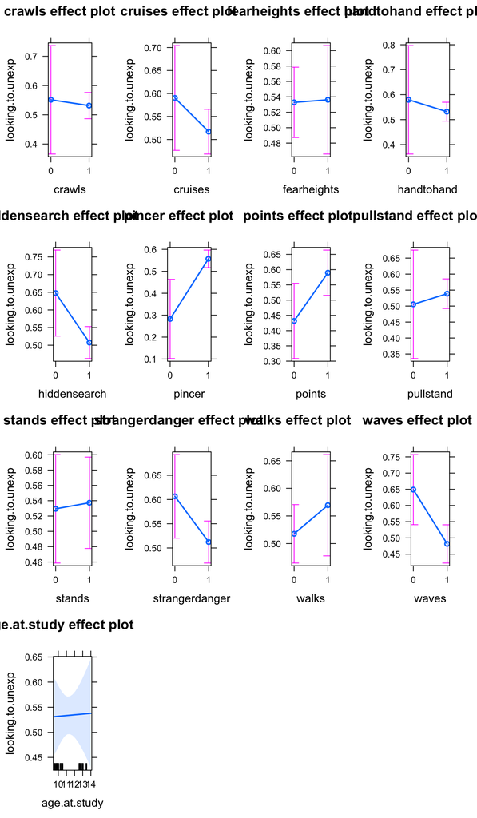

```r
plot(allEffects(model3))
```

```r
LT_data_months <- full_data %>%
  select(subj, agegroup, age.at.study, exp, action, monthsPerformed, looking.to.unexp, LTdiff) %>%
  # mutate(yesnoAtStudy = as.factor(yesnoAtStudy)) %>%
  spread(action, monthsPerformed)

LT_data_months_MR <- LT_data_months %>%
  filter(exp=="MR")

LT_data_months_RISK <- LT_data_months %>%
  filter(exp=="RISK")

model3 <- lm(looking.to.unexp ~ cruises + points + pullstand + stands + walks + waves, data=LT_data_months_MR)
summary(model3)
```

```
##
## Call:
## lm(formula = looking.to.unexp ~ cruises + points + pullstand +
##     stands + walks + waves, data = LT_data_months_MR)
##
## Residuals:
##      Min       1Q   Median       3Q      Max
## -0.18047 -0.07895 -0.00414  0.08174  0.14080
##
## Coefficients:
##             Estimate Std. Error t value Pr(>|t|)
## (Intercept)   0.5449     0.0779    6.99  3.8e-05 ***
## cruises      -0.0285     0.0453   -0.63     0.54
## points        0.0251     0.0284    0.88     0.40
## pullstand     0.0564     0.0389    1.45     0.18
## stands       -0.0900     0.0668   -1.35     0.21
## walks         0.0877     0.0595    1.47     0.17
## waves        -0.0106     0.0203   -0.52     0.61
## ---
## Signif. codes:  0 '***' 0.001 '**' 0.01 '*' 0.05 '.' 0.1 ' ' 1
##
## Residual standard error: 0.122 on 10 degrees of freedom
##   (43 observations deleted due to missingness)
## Multiple R-squared:  0.292,  Adjusted R-squared:  -0.132
## F-statistic: 0.688 on 6 and 10 DF,  p-value: 0.665
```

```r
# plot(allEffects(model3))
#
model4 <- lm(looking.to.unexp ~ cruises + points + pullstand + stands + walks + waves, data=LT_data_months_RISK)
summary(model4)
```

```
##
## Call:
## lm(formula = looking.to.unexp ~ cruises + points + pullstand +
##     stands + walks + waves, data = LT_data_months_RISK)
##
## Residuals:
##     Min      1Q  Median      3Q     Max
## -0.2771 -0.0580  0.0273  0.0690  0.2077
##
## Coefficients:
##             Estimate Std. Error t value Pr(>|t|)
## (Intercept)  0.47831    0.04837    9.89  3.8e-09 ***
## cruises      0.00355    0.02216    0.16     0.87
## points       0.01344    0.01013    1.33     0.20
## pullstand    0.01592    0.01908    0.83     0.41
## stands      -0.00699    0.01857   -0.38     0.71
## walks       -0.02517    0.01753   -1.44     0.17
## waves       -0.00945    0.01057   -0.89     0.38
## ---
## Signif. codes:  0 '***' 0.001 '**' 0.01 '*' 0.05 '.' 0.1 ' ' 1
##
## Residual standard error: 0.121 on 20 degrees of freedom
##   (37 observations deleted due to missingness)
## Multiple R-squared:  0.216,  Adjusted R-squared:  -0.0189
## F-statistic: 0.92 on 6 and 20 DF,  p-value: 0.502
```

```r
# plot(allEffects(model4))

model5 <- lm(looking.to.unexp ~ crawls + cruises + fearheights + handtohand + hiddensearch + pincer + points + pullstand + stands + strangerdanger + walks + waves + age.at.study, data=LT_data_months, na.action=na.exclude)
summary(model5)
```

```
##
## Call:
## lm(formula = looking.to.unexp ~ crawls + cruises + fearheights +
##     handtohand + hiddensearch + pincer + points + pullstand +
##     stands + strangerdanger + walks + waves + age.at.study, data = LT_data_months,
##     na.action = na.exclude)
##
## Residuals:
##        5       14       25       28       43       70       72       74
##  0.02815 -0.01661  0.03439 -0.01949  0.03913 -0.04484 -0.02946  0.05724
##       82       87       91       93       94       97       98      104
##  0.09354  0.00357 -0.02981  0.07743 -0.08012 -0.04333  0.01968  0.01141
##      105      127      129
## -0.02442 -0.01764 -0.05882
##
## Coefficients:
##                Estimate Std. Error t value Pr(>|t|)
## (Intercept)     1.50528    0.53899    2.79    0.038 *
## crawls          0.00666    0.02248    0.30    0.779
## cruises         0.13953    0.04155    3.36    0.020 *
## fearheights    -0.01634    0.01074   -1.52    0.189
## handtohand      0.00893    0.01302    0.69    0.523
## hiddensearch   -0.02351    0.02039   -1.15    0.301
## pincer          0.03904    0.02024    1.93    0.112
## points          0.05162    0.01548    3.34    0.021 *
## pullstand      -0.00279    0.02229   -0.13    0.905
## stands         -0.05443    0.03113   -1.75    0.141
## strangerdanger  0.03293    0.01238    2.66    0.045 *
## walks          -0.07508    0.03994   -1.88    0.119
## waves          -0.03100    0.01622   -1.91    0.114
## age.at.study   -0.12002    0.04844   -2.48    0.056 .
## ---
## Signif. codes:  0 '***' 0.001 '**' 0.01 '*' 0.05 '.' 0.1 ' ' 1
##
## Residual standard error: 0.0885 on 5 degrees of freedom
##   (111 observations deleted due to missingness)
## Multiple R-squared:  0.878,  Adjusted R-squared:  0.562
## F-statistic: 2.78 on 13 and 5 DF,  p-value: 0.133
```

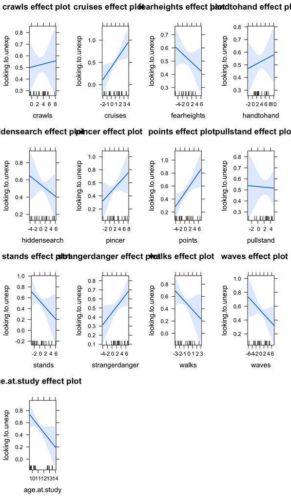

```r
plot(allEffects(model5))
```